# Ryzyko portfela: VaR i CVaR metodą Monte Carlo

Portfel 5 spółek z GPW, 100 000 PLN, dane 2015-2026

Opublikowano

13 października 2026

**Ostrzeżenie**

**Projekt edukacyjny.** Raport ilustruje metody pomiaru ryzyka na danych historycznych. Nie jest rekomendacją inwestycyjną ani oceną spółek.

# 1 Streszczenie

- Portfel: po 20% w PKO BP, PZU, CD Projekt, KGHM i Orlen, wartość 100 000 PLN. Dane dzienne z Yahoo Finance, 2015-01-05 – 2026-10-02 (2938 sesji).
- **Jednodniowy VaR 99%** wynosi od 3 395 PLN (rozkład normalny) do 3 741 PLN (Monte Carlo z t-Studentem). Metody różnią się niewiele przy VaR, ale bardzo przy **CVaR 99%**: normalny 3 887 PLN, historyczny 5 049 PLN. Rozkład normalny zaniża średnią stratę w najgorszym 1% dni o około 23%.
- Zwroty mają **grube ogony** (kurtoza nadwyżkowa portfela 3,80) i **skupiska zmienności** (silna autokorelacja kwadratów zwrotów).
- **Horyzont 10 dni:** metody zakładające niezależne dni (normalna, MC) dają VaR 99% ok. 10 068 PLN, a historyczne 10-dniowe okna 12 077 PLN. Spadki przychodzą seriami, więc metody zakładające niezależne dni zaniżają ryzyko wielodniowe o ok. 15–20%.
- **Backtest** (2438 dni, okno 500): przy 99% oczekujemy 24,4 przekroczeń. Normalny ma 42 (test Kupca odrzuca), historyczny i MC-t po 32 (Kupiec przechodzi, ale przekroczenia tworzą skupiska: Christoffersen odrzuca). GARCH najlepiej reaguje na marzec 2020, ale jego podstawowa wersja przy 99% też ma za dużo przekroczeń.

# 2 Dane i kontrola jakości

Surowe dane z Yahoo Finance (przed czyszczeniem)

| ticker | pierwszy_dzien | ostatni_dzien | wiersze | braki_adjusted | wolumen_zero | ujemne_lub_zero_ceny |
| --- | --- | --- | --- | --- | --- | --- |
| PKO.WA | 2015-01-01 | 2026-10-12 | 2995 | 1 | 55 | 0 |
| PZU.WA | 2015-01-01 | 2026-10-12 | 2995 | 1 | 55 | 0 |
| CDR.WA | 2015-01-01 | 2026-10-12 | 2995 | 1 | 55 | 0 |
| KGH.WA | 2015-01-01 | 2026-10-12 | 2995 | 1 | 55 | 0 |
| PKN.WA | 2015-01-01 | 2026-10-12 | 2995 | 1 | 55 | 0 |

Co znalazłem i jak to obsłużyłem:

1. **Sztuczne wiersze z zerowym wolumenem** (55 dni, wspólne dla wszystkich spółek): święta GPW do 2020 r. (Yahoo wstawiało cenę z poprzedniego dnia) oraz kilka pojedynczych dziur. Cena się w nie nie zmienia, więc usunąłem je. Zostawienie ich wstawiłoby sztuczne zerowe zwroty i zaniżyło zmienność.
2. **Dziura na końcu próby:** 5–9.10.2026 cała seria jest płaska z zerowym wolumenem, a 12.10.2026 to niepełna sesja (brak ceny zamknięcia). Próbę kończę na **2026-10-02**, ostatnim wiarygodnym dniu.
3. **Splity:** Yahoo zgłasza tylko split PZU 1:10 (30.11.2015). Ceny są już o niego skorygowane (brak skoku w szeregu).
4. **Dywidendy:** cena *Adjusted* uwzględnia dywidendy. W 38 dniach zwrot z *Adjusted* różni się od zwrotu z *Close* o więcej niż 1 pp. To dni odcięcia dywidendy (PZU i Orlen co roku, PKO BP, KGHM). Bez korekty liczylibyśmy dywidendę jako stratę.
5. **Luki między sesjami:** najdłuższa przerwa to 6 dni kalendarzowych. Wszystkie luki powyżej 4 dni to Wielkanoc i Boże Narodzenie.
6. **Obserwacje odstające** (|zwrot| > 6 odchyleń standardowych) to prawdziwe zdarzenia, więc je zostawiłem:

Zwroty dzienne powyżej 6 sd (opisy zdarzeń: kontekst rynkowy, nie analiza przyczyn)

| ticker | data | zwrot | ile_sd | kontekst |
| --- | --- | --- | --- | --- |
| PKO BP | 2020-03-12 | -0.1387 | -6.8 | COVID, krach na rynkach |
| PKO BP | 2022-02-24 | -0.1842 | -9.0 | Inwazja Rosji na Ukrainę |
| PKO BP | 2022-02-25 | 0.1246 | 6.1 | Odbicie po 24.02.2022 |
| PKO BP | 2025-08-22 | -0.1304 | -6.4 | zdarzenie specyficzne dla spółki |
| PZU | 2020-03-12 | -0.1180 | -6.9 | COVID, krach na rynkach |
| CD Projekt | 2015-06-09 | 0.1863 | 7.0 | zdarzenie specyficzne dla spółki |
| CD Projekt | 2021-01-29 | -0.1789 | -6.7 | zdarzenie specyficzne dla spółki |
| KGHM | 2020-03-12 | -0.1742 | -6.7 | COVID, krach na rynkach |
| Orlen | 2020-11-09 | 0.1345 | 6.4 | Ogłoszenie skuteczności szczepionki, rajd |

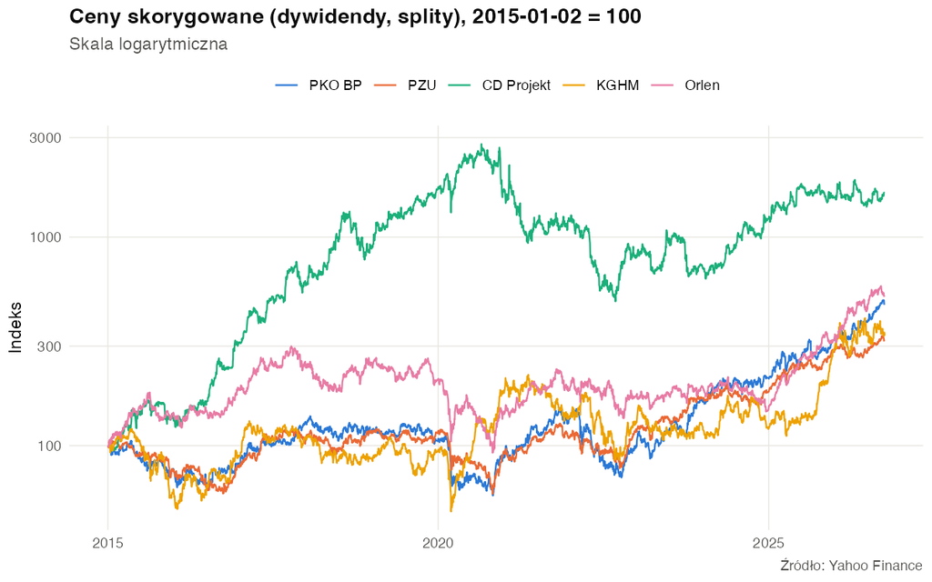

Rysunek 1: Ceny skorygowane, indeks 100 na starcie

# 3 Eksploracja zwrotów

Statystyki dziennych zwrotów logarytmicznych

| seria | srednia_dzienna | zmiennosc_roczna | min | max | skosnosc | kurtoza_nadwyzkowa | JB_p |
| --- | --- | --- | --- | --- | --- | --- | --- |
| PKO BP | 0.00053 | 0.324 | -0.184 | 0.1250 | -0.3170 | 5.64 | 0 |
| PZU | 0.00039 | 0.270 | -0.118 | 0.0823 | -0.1310 | 2.69 | 0 |
| CD Projekt | 0.00095 | 0.424 | -0.179 | 0.1860 | -0.0959 | 4.34 | 0 |
| KGHM | 0.00043 | 0.413 | -0.174 | 0.1100 | -0.0797 | 2.30 | 0 |
| Orlen | 0.00056 | 0.332 | -0.101 | 0.1340 | -0.0363 | 1.86 | 0 |
| Portfel | 0.00057 | 0.240 | -0.130 | 0.0843 | -0.3050 | 3.80 | 0 |

Każda spółka i portfel mają ujemną skośność i kurtozę nadwyżkową wyraźnie powyżej 0. Test Jarque-Bera odrzuca normalność przy każdym rozsądnym poziomie istotności. Dywersyfikacja działa: zmienność portfela (24,0% rocznie) jest niższa niż zmienność każdej spółki z osobna.

**Histogramy**

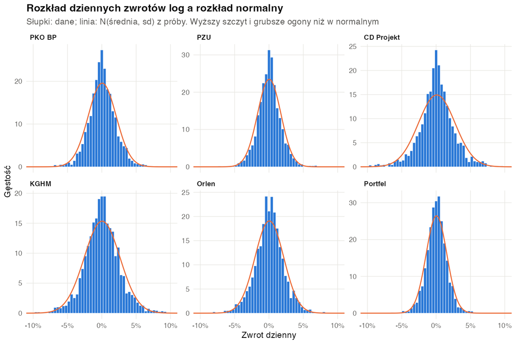

**QQ-plot**

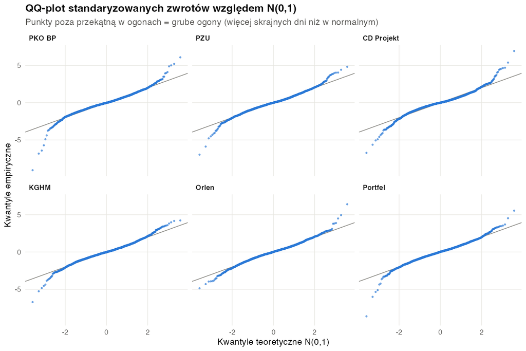

**Dni poniżej −3 sd**

Liczba dni ze zwrotem poniżej −3 sd vs liczba oczekiwana w rozkładzie normalnym

| seria | dni_ponizej_3sd | oczekiwane_normalny |
| --- | --- | --- |
| PKO BP | 18 | 4 |
| PZU | 15 | 4 |
| CD Projekt | 27 | 4 |
| KGHM | 13 | 4 |
| Orlen | 17 | 4 |
| Portfel | 16 | 4 |

**Autokorelacja.** Same zwroty portfela prawie nie mają pamięci (Ljung-Box, 10 opóźnień: p = 0,123), ale ich kwadraty mają silną i długą autokorelację. To typowy efekt skupisk zmienności (ARCH): po dniu dużej zmiany częściej przychodzi kolejny dzień dużej zmiany. Właśnie to założenie łamią wszystkie metody „iid” i dlatego w rozdziale 7 testuję GARCH.

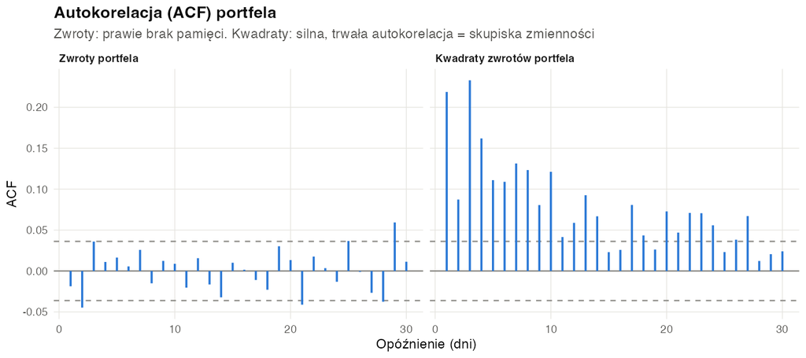

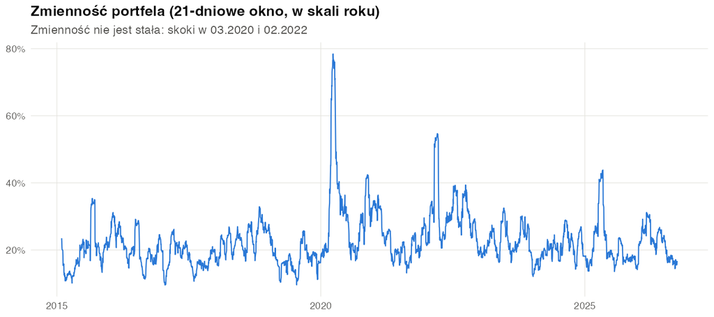

**Korelacje.** Średnia korelacja par spółek to 0,34, ale w 20% dni o najwyższej zmienności (mierzonej na poprzednich 21 sesjach) rośnie do 0,41. Dywersyfikacja słabnie właśnie wtedy, gdy jest najbardziej potrzebna.

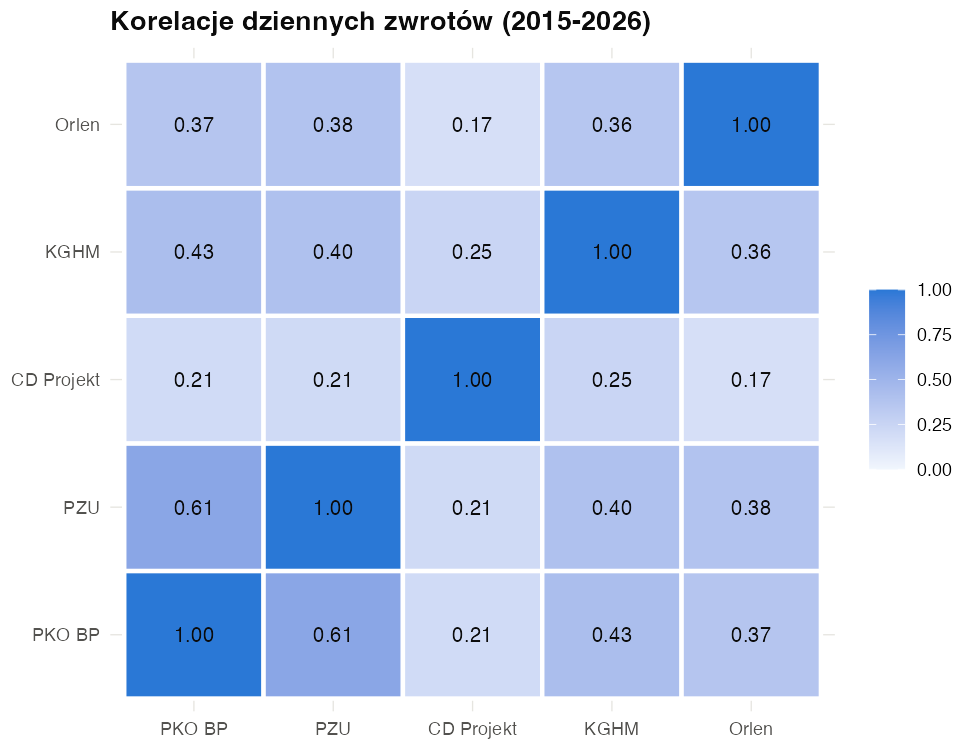

# 4 VaR i CVaR: metoda historyczna i parametryczna

Strata w PLN to $L = V\,(1 - e^{r})$, gdzie $r$ to logarytmiczny zwrot portfela w horyzoncie, a $V$ = 100 000 PLN. **VaR** na poziomie $\alpha$ to strata, której nie przekroczymy z prawdopodobieństwem $\alpha$. **CVaR** (Expected Shortfall) to średnia strata w dniach, w których VaR został przekroczony.

- **Historyczna:** kwantyl empiryczny zwrotów portfela. Dla 10 dni używam zachodzących na siebie 10-dniowych okien.
- **Parametryczna normalna:** $r_h \sim N(h\mu,\, h\sigma^2)$. CVaR liczony dokładnym wzorem dla straty $V(1-e^r)$ przy normalnym $r$.

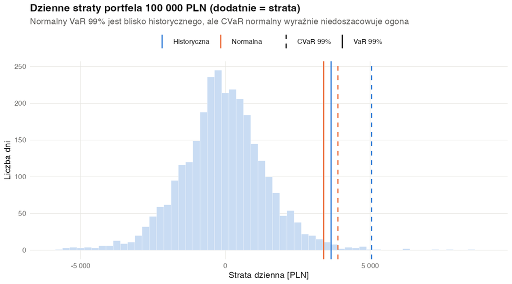

Rysunek 2

**Kod: VaR/CVaR z próby i z rozkładu normalnego (R/ryzyko.R)**

```r
var_cvar_probka
```

```
function (r, alfa, V = WARTOSC)
{
    q <- quantile(r, 1 - alfa, names = FALSE, type = 7)
    c(VaR = strata_pln(q, V), CVaR = mean(strata_pln(r[r <= q],
        V)))
}
```

**Kod: VaR/CVaR z próby i z rozkładu normalnego (R/ryzyko.R)**

```r
var_cvar_normalny
```

```
function (mu, sigma, alfa, h = 1, V = WARTOSC)
{
    m <- mu * h
    s <- sigma * sqrt(h)
    p <- 1 - alfa
    q <- m + qnorm(p) * s
    e_exp <- exp(m + s^2/2) * pnorm((q - m - s^2)/s)/p
    c(VaR = strata_pln(q, V), CVaR = V * (1 - e_exp))
}
```

# 5 Monte Carlo

Symuluję dzienne zwroty 5 spółek z zachowaniem korelacji (rozkład Choleskiego macierzy kowariancji $\Sigma = U^\top U$, $X = \mu + Z U$), liczę zwrot portfela i sumuję dni w horyzoncie. Trzy warianty:

1. **MC normalny:** $Z \sim N(0, I)$. Służy jako kontrola poprawności, bo musi zbiec do wzoru parametrycznego.
2. **MC t-Student:** wielowymiarowy rozkład t ze wspólnym mianownikiem $\sqrt{(\nu-2)/W}$, $W\sim\chi^2_\nu$. Krach dotyka wtedy wszystkich spółek naraz (zależność w ogonach), a kowariancja dalej równa się $\Sigma$. Stopnie swobody $\nu$ estymuję metodą największej wiarygodności: **ν = 5,97**.
3. **MC bootstrap:** losowanie całych historycznych dni ze zwracaniem. Zachowuje rzeczywiste ogony i korelacje, ale nie zachowuje kolejności dni.

Stopnie swobody t-Studenta (MLE): wielowymiarowy i jednowymiarowe

|  | seria | nu |
| --- | --- | --- |
|  | Wielowymiarowy t (5 spółek, MLE) | 5.97 |
| PKO.WA | PKO BP | 4.90 |
| PZU.WA | PZU | 5.26 |
| CDR.WA | CD Projekt | 3.45 |
| KGH.WA | KGHM | 5.31 |
| PKN.WA | Orlen | 5.88 |
| Portfel | Portfel | 5.79 |

Wszystkie symulacje są wektorowe: jedna macierz $n \cdot h \times 5$ i mnożenie macierzy, bez pętli po scenariuszach. Ziarno: `set.seed(2.0261013\times 10^{7})`, $N$ = 100 000.

**Kod: symulacja t-Studenta (R/mc.R)**

```r
sim_mc_t
```

```
function (n, mu, Sigma, nu, w = WAGI, h = 1)
{
    U <- chol(Sigma)
    m <- n * h
    Z <- matrix(rnorm(m * length(mu)), ncol = length(mu))
    skala <- sqrt((nu - 2)/rchisq(m, df = nu))
    X <- sweep((Z %*% U) * skala, 2, mu, "+")
    sumuj_horyzont(as.numeric(X %*% w), n, h)
}
```

**Kontrola poprawności.** Przy $10^6$ symulacji MC normalny trafia we wzór parametryczny, a MC-t w dokładny kwantyl rozkładu t. Portfel z wielowymiarowego t o wspólnym ν ma bowiem jednowymiarowy rozkład t. Błędy są poniżej 1%:

MC (10^6 symulacji) vs wartość dokładna; błąd w %

| model | alfa | horyzont | VaR_MC | VaR_wzor | CVaR_MC | CVaR_wzor | blad_VaR_proc | blad_CVaR_proc |
| --- | --- | --- | --- | --- | --- | --- | --- | --- |
| normalny | 0.95 | 1 | 2393.07 | 2396.22 | 3008.76 | 3008.31 | -0.13 | 0.01 |
| normalny | 0.99 | 1 | 3399.33 | 3394.99 | 3895.84 | 3886.75 | 0.13 | 0.23 |
| normalny | 0.95 | 10 | 7004.68 | 7020.33 | 8829.09 | 8842.08 | -0.22 | -0.15 |
| normalny | 0.99 | 10 | 9974.68 | 9995.95 | 11419.65 | 11430.21 | -0.21 | -0.09 |
| t-Student | 0.95 | 1 | 2310.76 | 2309.64 | 3217.58 | 3225.52 | 0.05 | -0.25 |
| t-Student | 0.99 | 1 | 3733.02 | 3745.13 | 4762.37 | 4790.54 | -0.32 | -0.59 |

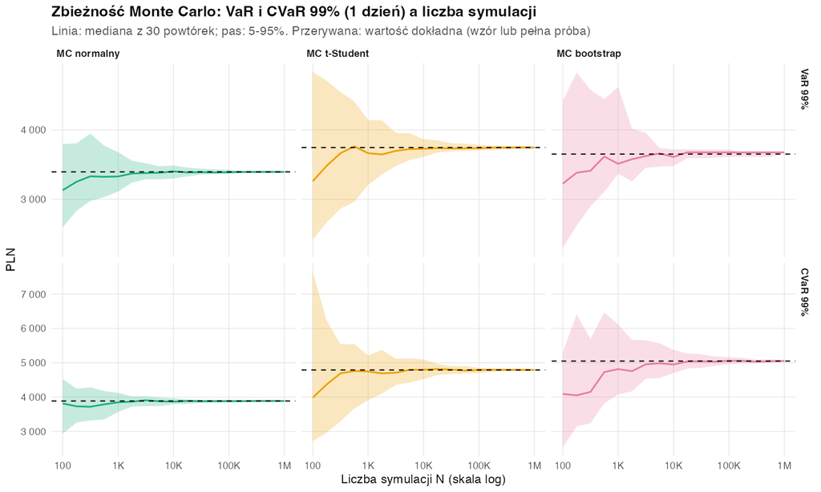

Rysunek 3

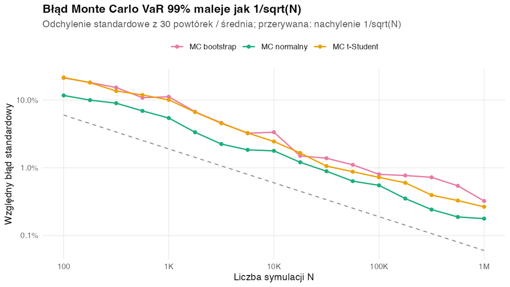

Rysunek 4

CVaR zbiega wolniej niż VaR, bo zależy od kilku najbardziej skrajnych scenariuszy. Przy 99% potrzeba ok. 10<sup>4</sup>–10<sup>5</sup> symulacji, żeby błąd spadł do ~1%. Błąd maleje jak $1/\sqrt{N}$: dziesięć razy dokładniej oznacza sto razy więcej symulacji.

# 6 Porównanie metod

VaR i CVaR [PLN] dla portfela 100 000 PLN (kolumny: miara_poziom_horyzont)

| metoda | VaR_95_1d | CVaR_95_1d | VaR_99_1d | CVaR_99_1d | VaR_95_10d | CVaR_95_10d | VaR_99_10d | CVaR_99_10d |
| --- | --- | --- | --- | --- | --- | --- | --- | --- |
| Historyczna | 2 324 | 3 262 | 3 652 | 5 049 | 6 850 | 10 378 | 12 077 | 16 585 |
| Normalna | 2 396 | 3 008 | 3 395 | 3 887 | 7 020 | 8 842 | 9 996 | 11 430 |
| MC normalny | 2 400 | 3 019 | 3 416 | 3 895 | 7 050 | 8 900 | 10 068 | 11 550 |
| MC t-Student | 2 301 | 3 222 | 3 741 | 4 797 | 6 992 | 8 967 | 10 211 | 11 850 |
| MC bootstrap | 2 312 | 3 264 | 3 611 | 5 069 | 7 056 | 9 221 | 10 496 | 12 628 |

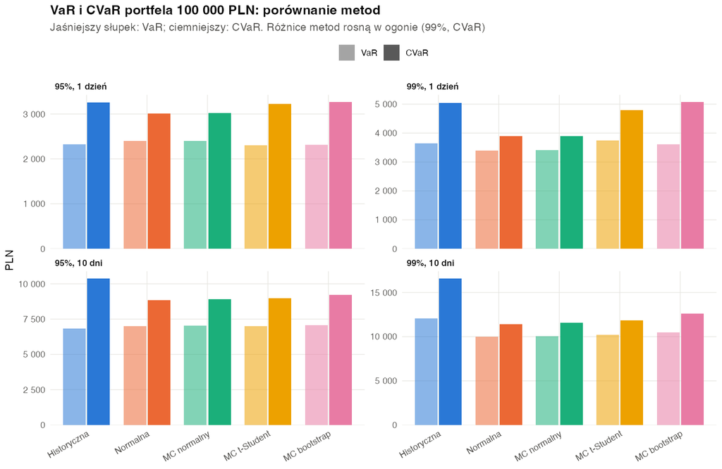

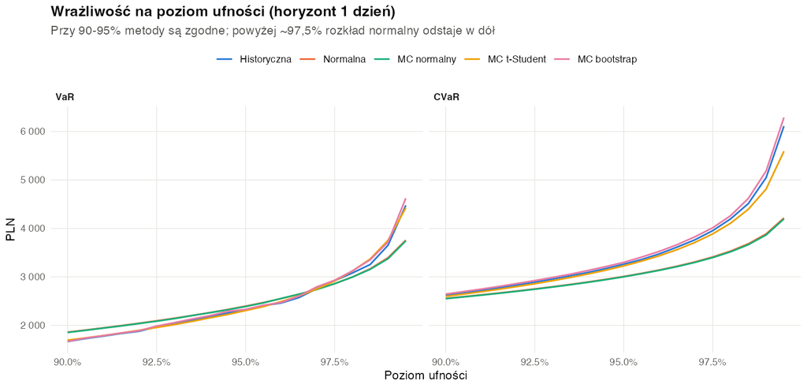

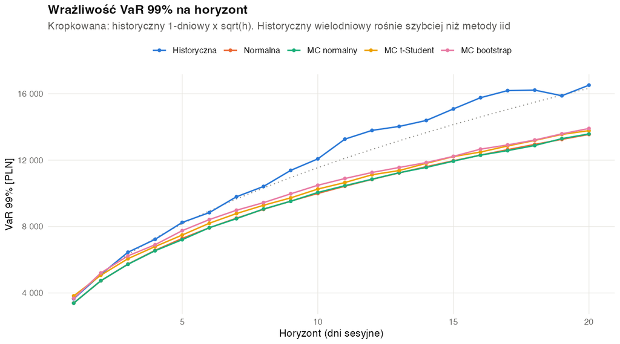

**Wnioski z porównania**

- Przy 95% wszystkie metody dają prawie to samo (2 301 PLN–2 400 PLN). Wybór metody ma znaczenie dopiero w ogonie.
- Przy 99% rozkład normalny zaniża VaR o kilka procent, a **CVaR o ~23%**. MC-t i bootstrap odtwarzają gruby ogon.
- Przy 10 dniach metody MC (t, bootstrap) zbliżają się do normalnej, bo suma 10 niezależnych dni „normalnieje” (CLT). Historyczne 10-dniowe straty są wyższe, bo dni nie są niezależne: spadki przychodzą seriami. Lepszy model niezależnych dni tego nie naprawi, potrzebny jest model zmiennej zmienności.

# 7 Backtest (okno kroczące 500 dni)

Dla każdego dnia $t$ od 2016-12-30 liczę VaR 1-dniowy **wyłącznie z 500 poprzednich dni** ($t-500, \dots, t-1$). Przekroczenie to dzień, w którym rzeczywisty zwrot był niższy niż prognozowany kwantyl. Brak look-ahead bias sprawdzam w kodzie dwoma sposobami: (1) po „zepsuciu” danych od dnia 1500 prognozy na wcześniejsze dni są bit w bit identyczne, (2) liczby przekroczeń i statystyki LR zgadzają się z `rugarch::VaRTest`.

- **Test Kupca (POF):** czy odsetek przekroczeń jest równy $1-\alpha$.
- **Test Christoffersena:** czy przekroczenia są niezależne (nie tworzą skupisk) oraz test łączny (*conditional coverage*).

Backtest VaR 1-dniowego, wszystkie metody (p < 0,05 = model odrzucony)

| metoda | alfa | dni | przekr. | oczek. | p Kupiec | przekr. dzień po dniu | p niezależność | p łączny | śr. VaR [PLN] |
| --- | --- | --- | --- | --- | --- | --- | --- | --- | --- |
| Historyczna | 0.95 | 2438 | 123 | 121.9 | 0.919 | 10 | 0.137 | 0.3301 | 2367 |
| Historyczna | 0.99 | 2438 | 32 | 24.4 | 0.139 | 3 | 0.008 | 0.0098 | 3626 |
| Normalna | 0.95 | 2438 | 119 | 121.9 | 0.787 | 12 | 0.017 | 0.0549 | 2426 |
| Normalna | 0.99 | 2438 | 42 | 24.4 | 0.001 | 4 | 0.006 | 0.0001 | 3434 |
| MC t-Student | 0.95 | 2438 | 128 | 121.9 | 0.574 | 12 | 0.050 | 0.1258 | 2348 |
| MC t-Student | 0.99 | 2438 | 32 | 24.4 | 0.139 | 4 | 0.001 | 0.0010 | 3751 |
| GARCH-norm | 0.95 | 2438 | 131 | 121.9 | 0.403 | 9 | 0.453 | 0.5318 | 2336 |
| GARCH-norm | 0.99 | 2438 | 43 | 24.4 | 0.001 | 3 | 0.045 | 0.0004 | 3316 |
| GARCH-t | 0.95 | 2438 | 133 | 121.9 | 0.309 | 10 | 0.306 | 0.3528 | 2308 |
| GARCH-t | 0.99 | 2438 | 37 | 24.4 | 0.017 | 3 | 0.019 | 0.0037 | 3581 |

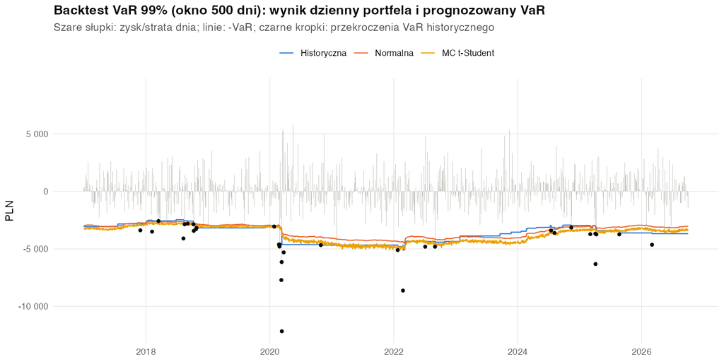

**Interpretacja**

- **Normalna 99%:** 42 przekroczeń zamiast ~24. Test Kupca odrzuca (p = 0,001). Rozkład normalny ma za cienkie ogony.
- **Historyczna i MC-t 99%:** liczba przekroczeń jest do przyjęcia (Kupiec p = 0,14), ale przekroczenia przychodzą seriami (Christoffersen odrzuca niezależność). Model ma dobrą średnią, ale zły moment: w spokojnych okresach przeszacowuje ryzyko, a w kryzysie je zaniża.
- **Przy 95%** wszystkie metody przechodzą test Kupca. Wtedy liczy się głównie środek rozkładu, a nie ogon.

## 7.1 Okres stresu: marzec 2020

Marzec 2020: przekroczenia VaR (oczekiwane przy poprawnym modelu: 0,22 dla 99%, 1,1 dla 95%)

| metoda | alfa | dni | przekroczenia | oczekiwane | p_dwumian | VaR_srednio_PLN |
| --- | --- | --- | --- | --- | --- | --- |
| Historyczna | 0.95 | 22 | 7 | 1.10 | 6.8e-05 | 2389 |
| Historyczna | 0.99 | 22 | 4 | 0.22 | 6.3e-05 | 4124 |
| Normalna | 0.95 | 22 | 7 | 1.10 | 6.8e-05 | 2490 |
| Normalna | 0.99 | 22 | 5 | 0.22 | 2.3e-06 | 3491 |
| MC t-Student | 0.95 | 22 | 7 | 1.10 | 6.8e-05 | 2450 |
| MC t-Student | 0.99 | 22 | 5 | 0.22 | 2.3e-06 | 3709 |
| GARCH-norm | 0.95 | 22 | 3 | 1.10 | 9.5e-02 | 5139 |
| GARCH-norm | 0.99 | 22 | 3 | 0.22 | 1.3e-03 | 7195 |
| GARCH-t | 0.95 | 22 | 3 | 1.10 | 9.5e-02 | 5198 |
| GARCH-t | 0.99 | 22 | 3 | 0.22 | 1.3e-03 | 7785 |

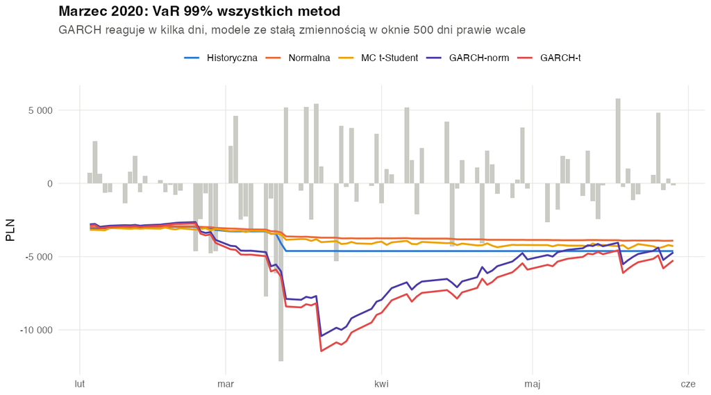

W marcu 2020 r. wszystkie modele bez zmiennej zmienności miały 4–5 przekroczeń VaR 99% w 22 sesjach (oczekiwane 0,22). Okno 500 dni zawiera prawie wyłącznie spokojny okres, więc jeden krach prawie nie zmienia kwantyla. VaR historyczny skoczył dopiero wtedy, gdy krach z 12.03 sam znalazł się w oknie.

# 8 Rozszerzenie: GARCH(1,1)

Model $\sigma_t^2 = \omega + \alpha\,\varepsilon_{t-1}^2 + \beta\,\sigma_{t-1}^2$ (pakiet `rugarch`) z innowacjami normalnymi lub t-Studenta. Estymacja w tym samym oknie kroczącym 500 dni, reestymacja co 20 dni (`ugarchroll`, `refit.window = "moving"`). Między reestymacjami zmienność aktualizuje się codziennie nowymi danymi, ale parametry pozostają stałe. W kodzie sprawdzam, że każde okno estymacji kończy się przed pierwszym dniem, na który model prognozuje.

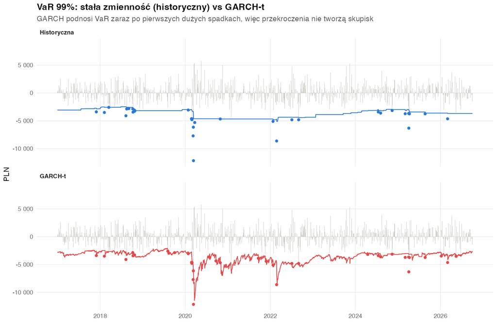

Przekroczenia VaR 99% w podziale na lata

| rok | Historyczna | Normalna | MC t-Student | GARCH-norm | GARCH-t | dni |
| --- | --- | --- | --- | --- | --- | --- |
| 2016 | 0 | 0 | 0 | 0 | 0 | 1 |
| 2017 | 1 | 1 | 1 | 1 | 1 | 250 |
| 2018 | 9 | 8 | 6 | 8 | 5 | 246 |
| 2019 | 0 | 1 | 0 | 3 | 3 | 248 |
| 2020 | 9 | 13 | 11 | 11 | 10 | 252 |
| 2021 | 0 | 2 | 0 | 2 | 2 | 251 |
| 2022 | 4 | 4 | 4 | 4 | 4 | 251 |
| 2023 | 0 | 0 | 0 | 0 | 0 | 250 |
| 2024 | 3 | 3 | 1 | 4 | 4 | 249 |
| 2025 | 5 | 5 | 5 | 5 | 5 | 249 |
| 2026 | 1 | 5 | 4 | 5 | 3 | 191 |

**Co daje GARCH**

- W marcu 2020 GARCH miał 3 przekroczenia zamiast 4–5, a jego VaR 99% wzrósł w ciągu kilku dni do ponad 10 000 PLN. Na tym polega wartość zmiennej zmienności: model ostrzega już w trakcie kryzysu, a nie dopiero po nim.
- Przy 95% GARCH ma najwyższe p-wartości testu niezależności (0,45 i 0,31), a model normalny bez GARCH jest w tym teście odrzucany. Przekroczenia przestają się grupować.
- Przy 99% podstawowy GARCH(1,1)-t ma jednak 37 przekroczeń (Kupiec p = 0,017). Średnio jest niższy niż VaR historyczny, bo w spokojnych latach szybko „zapomina” o ryzyku. Dodatkowo estymowana średnia dzienna z hossy (np. 2025–2026) obniża prognozowany kwantyl.

**Odporność specyfikacji GARCH-t** (wariant główny ustalony z góry: sGARCH ze stałą w średniej):

Warianty GARCH-t w backteście

| model | srednia_w_modelu | alfa | przekroczenia | oczekiwane | p_kupiec | p_christoffersen_cc |
| --- | --- | --- | --- | --- | --- | --- |
| sGARCH | TRUE | 0.95 | 133 | 121.90 | 0.309 | 0.353 |
| sGARCH | TRUE | 0.99 | 37 | 24.38 | 0.017 | 0.004 |
| gjrGARCH | TRUE | 0.95 | 124 | 121.90 | 0.846 | 0.942 |
| gjrGARCH | TRUE | 0.99 | 34 | 24.38 | 0.065 | 0.144 |
| sGARCH | FALSE | 0.95 | 123 | 121.90 | 0.919 | 0.942 |
| sGARCH | FALSE | 0.99 | 35 | 24.38 | 0.042 | 0.006 |
| gjrGARCH | FALSE | 0.95 | 115 | 121.90 | 0.518 | 0.785 |
| gjrGARCH | FALSE | 0.99 | 32 | 24.38 | 0.139 | 0.248 |

Oba warianty asymetrycznego GJR-GARCH (spadki zwiększają zmienność mocniej niż wzrosty) przechodzą testy Kupca i Christoffersena na obu poziomach przy α = 5%. Najlepiej wypada wariant bez stałej w średniej. Ten wariant wybrałem jednak *po* obejrzeniu wyników, więc traktuję go jako wskazówkę do dalszej pracy, a nie dowód.

**Bieżąca prognoza GARCH-t** (ostatnie 500 dni, stan na 2026-10-02):

GARCH-t: VaR/CVaR na kolejny dzień i 10 dni (10 dni: 50 000 symulowanych ścieżek GARCH)

| metoda | alfa | horyzont | VaR | CVaR | sigma_dzienna_teraz | sigma_dzienna_dlugookresowa |
| --- | --- | --- | --- | --- | --- | --- |
| GARCH-t | 0.95 | 1 | 1783 | 2364 | 1,21% | 1,37% |
| GARCH-t | 0.99 | 1 | 2718 | 3257 | 1,21% | 1,37% |
| GARCH-t | 0.95 | 10 | 4608 | 6352 | 1,21% | 1,37% |
| GARCH-t | 0.99 | 10 | 7373 | 8910 | 1,21% | 1,37% |

Bieżąca zmienność (1,21% dziennie) jest niższa niż poziom długookresowy wynikający z parametrów modelu i niż średnia z 2015–2026 (1,51%), więc GARCH podaje dziś *niższy* VaR niż metody statyczne. To zgodne z modelem, ale niesie ryzyko: niska zmienność potrafi się skończyć z dnia na dzień.

# 9 Ograniczenia

**Ostrzeżenie**

Projekt edukacyjny. Wyniki nie stanowią rekomendacji inwestycyjnej.